# Nonnegative Matrix Factorization (NMF) and Archetypal Analysis Examples

Statistics 185

10/8/2019

This document contains comparative examples of NMF and Archetypal Analysis applied to data from [MNIST](http://yann.lecun.com/exdb/mnist/) (LeCun et al.) containing pixelated images each viewed as a random vector.

To reduce the computation burden, we will only consider the first 200 4s from the MNIST data stored in the list *digits*. We show the first 25 such images below (some of which are upside down).

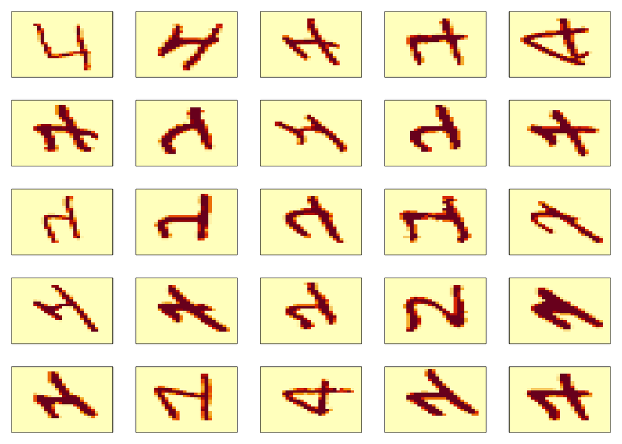

## Nonnegative Matrix Factorization

To compute the NMF of these data we use the package *NMF* and command *nmf*. Among other arguments *nmf* takes

```
i. *x* the data matrix,

ii. *rank* the desired rank,

iii. *method* the method to calculating estimation error, and

iv. *nrun* the number of runs to try at each rank.
```

Thus, a single rank 3 NMF using the Frobenius norm can be found using the command

```r
out <- nmf(digits4,3, method = "Frobenius")
# out <- nmf(digits4, 3, method = "KL") # for divergence
```

The output *out* above contains the weights in matrix *out@fit@W* and features in *out@fit@H* and we can visual the features by generating images from the rows of *out@fit@H* which notably look like 4s!

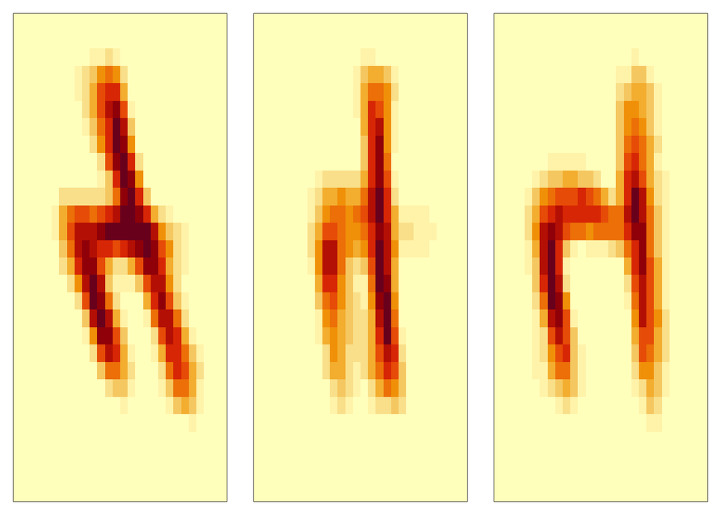

Compare these images to the mean and first 2 principal components. Note, we cannot conduct PCA using only 200 samples from 784-dimensional space!!! For PCA, we expand to consider the first 800 4s.

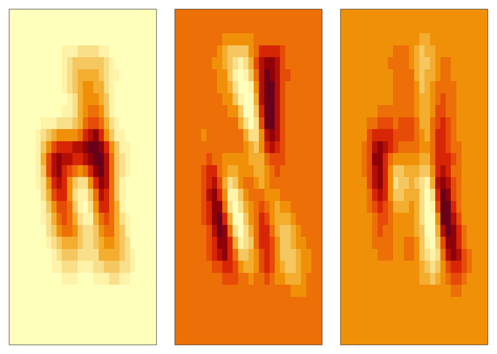

```r
N <- 800
out.pca <- princomp(digits$pixels[digits$labels == 4,][1:N,])
par(mar=c(1,1,1,1))
par(mfrow = c(1,3))
image(matrix(out.pca$center, nrow = 28),
        xaxt = 'n', yaxt = 'n')
for (j in 1:2){
  image(matrix(out.pca$loadings[,j], nrow = 28),
        xaxt = 'n', yaxt = 'n')
}
```

While the mean appears like a 4, the first and second principal component loadings appear less “4-like” thank their counterparts in NMF.

However, a rank 3 approximation (particularly based on a single run of NMF) may not be optimal. Let us compare ranks $1,\dots, 10$ each with 5 separate runs of the *NMF* algorithm.

```r
out <- nmf(digits4, rank = 1:10, nrun = 5, method = "Frobenius")
#takes ~ 10 minutes to run
```

The above calculation reports the performance of the best fit at each rank allowing us to plot the residual, $\frac{1}{2}\|X-WH\|^2$, as a function of rank. Note: This plot provides information akin to the scree plot in PCA.

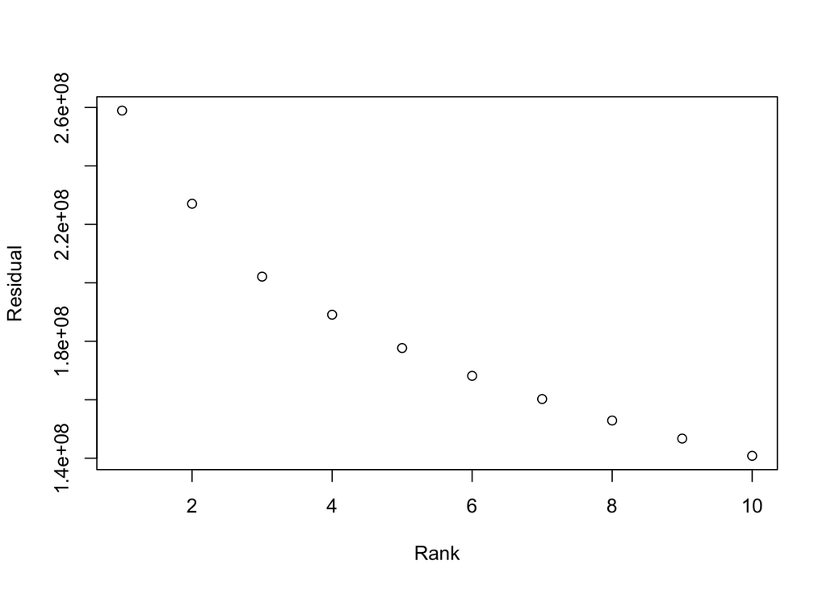

The output *out* also contains the best weight and feature matrices, $W$ and $H$ respectively, at each rank. Below we visualize the first 10 NMF features founds from the best rank $10$ NMF.

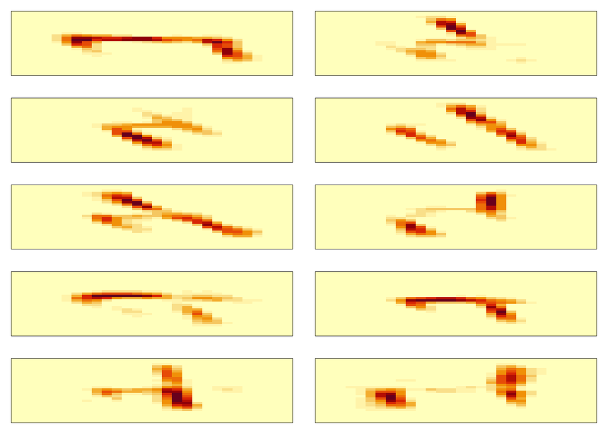

```r
H <- out$fit$`10`@fit@H
par(mar=c(1,1,1,1))
par(mfrow = c(5,2))
for (j in 1:10){
  image(matrix(H[j,],nrow = 28),
        xaxt = 'n', yaxt = 'n')
}
```

While these image are “4-like” than the rank 3 approximation they do contain pieces of 4s and they avoid the catastrophic cancelation inherent to PCA manifested in the neighboring regions of light(low pixel intensity) and dark(high pixel intensity). See the following block containing images based on the mean and first 9 principal component loadings!

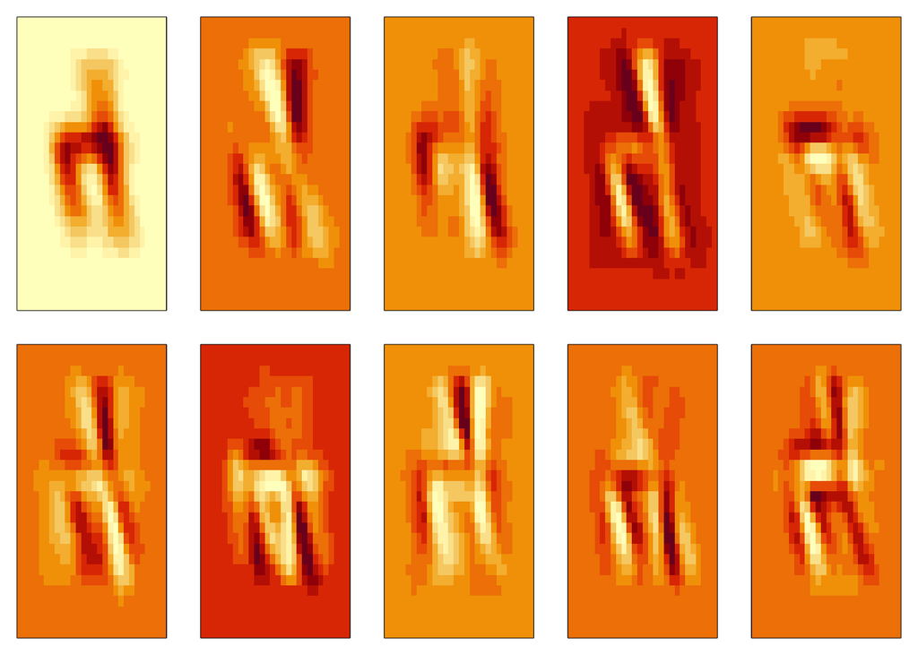

## Archetypal Analysis

To compute the Archetypes of these data we use the package *archetypes* and the commands *archetypes* and *stepArchetypes*. Among other arguments these functions accept

```
i. *data* the data matrix,

ii. *k* the desired rank,

iii. *nrep* the number of runs to try for each number of archetypes.
```

The *archetype* package assumes the Frobenius norm for all errors/residuals. For a single fixed number of archetypes we use *archetype()*. For comparison of differing numbers of archetypes, we use *stepArchetypes*. Details are shown below. Importantly, this algorithm will error out if any of the columns in the data matrix are identically zero requiring us to remove them prior to analysis of the data.

An archetype analysis assuming 3 archetypes and one run of the algorithm is shown below.

```r
out <- archetypes(digits4[,-zerocol], k = 3,
                  family = archetypesFamily("original",
                                            zalphasfn =archetypes:::ginv.zalphasfn)
                  )
```

The output *out* above contains the weights in matrix *out@fit@W* and features in *out@fit@H* and we can visual the archetypes by generating images from the rows of *out$archetypes* which notably look like 4s!

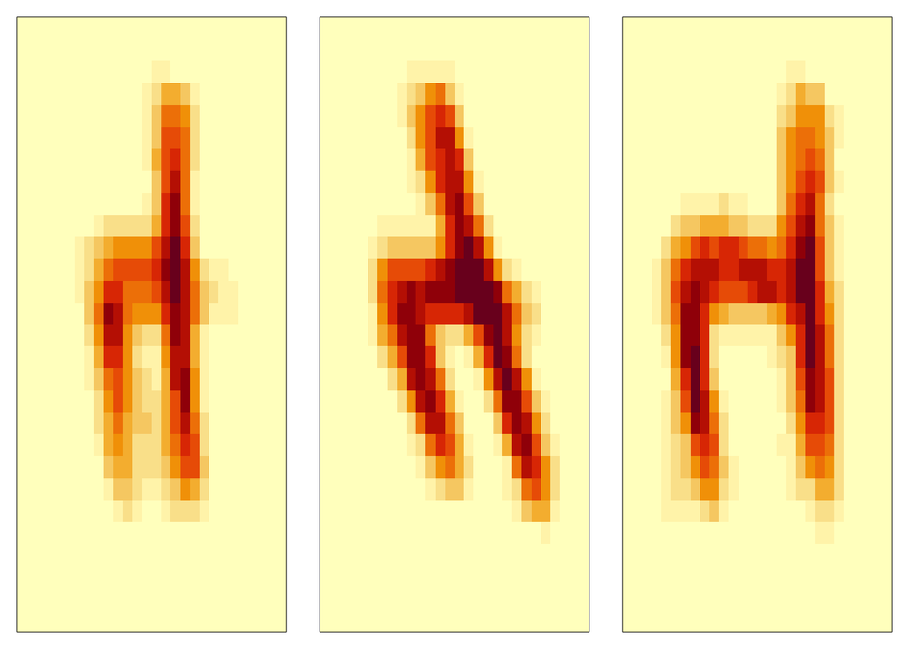

```r
out <- stepArchetypes(digits4[,-zerocol], k = 1:10, nrep = 5,
                  family = archetypesFamily("original",
                                            zalphasfn =archetypes:::ginv.zalphasfn),
                  verbose = FALSE
                  )
#takes ~ 10 minutes to run
# the family addition specifies a more robust algorithm.
```

The above calculation reports the performance of the best fit for each number of archetypes allowing us to plot the residual, $\frac{1}{2}\|X-WH\|^2$, as a function of rank. Note: This plot provides information akin to the scree plot in PCA. However, the Residual here cannot be compared directly to the NMF since we had to remove all columns which were identically zero. As a result, the fits here are in much lower dimensions and will naturally have smaller errors/residuals.

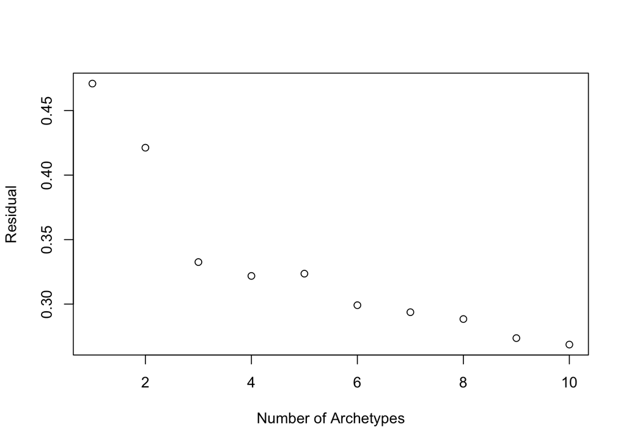

The output *out* also contains the best weight and feature matrices, $W$ and $H$ respectively, at each rank. Below we visualize the archetypes found from the best 10 archetype NMF.

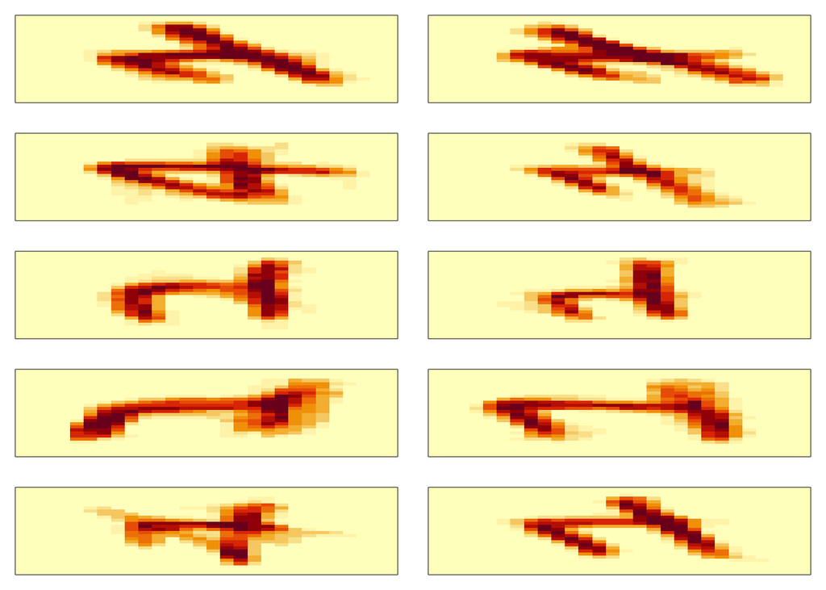

```r
  H <- bestModel(out[[10]])$archetypes
par(mar=c(1,1,1,1))
par(mfrow = c(5,2))
for (j in 1:10){
  temp <- rep(0,784); temp[-zerocol] <- H[j,]
  image(matrix(temp,nrow = 28),
        xaxt = 'n', yaxt = 'n')
}
```